# Quantitative Portfolio Analysis

### 3.6. Compare and Contrast Portfolio Metrics

Calculate and display the Sharpe ratio and diversification ratio for $\phi_{NRF}$, $\phi_{WRF}$, $\phi_{TEV}$, and the four optimal portfolios calculated in this section.

Compare and contrast these portfolios based on these metrics.

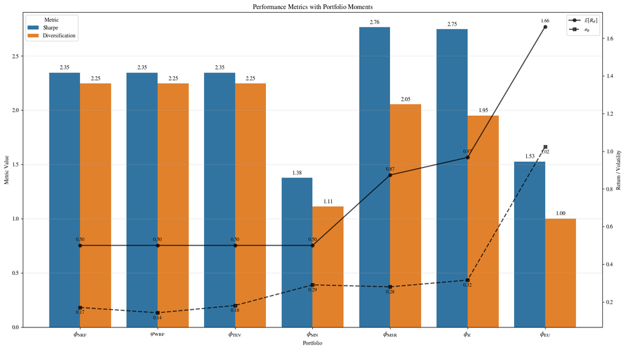

```python
phi_nrf_metrics = MV.mean_variance_no_risk_free_metrics.get_metrics()
varphi_wrf_metrics = MV.mean_variance_no_risk_free_metrics.get_metrics()
varphi_tev_metrics = TEV.tev_metrics.get_metrics()
phi_mn_metrics = beta_neutral_performance_metrics.get_metrics()
phi_msr_metrics = max_sharpe_performance_metrics.get_metrics()
phi_k_metrics = kelly_mean_variance_performance_metrics.get_metrics()
phi_eu_metrics = exponential_utility_performance_metrics.get_metrics()

index = pd.MultiIndex.from_tuples(
    [
        ("phi_nrf", "Sharpe"),
        ("phi_nrf", "Diversification"),
        ("phi_wrf", "Sharpe"),
        ("phi_wrf", "Diversification"),
        ("phi_tev", "Sharpe"),
        ("phi_tev", "Diversification"),
        ("phi_mn", "Sharpe"),
        ("phi_mn", "Diversification"),
        ("phi_msr", "Sharpe"),
        ("phi_msr", "Diversification"),
        ("phi_k", "Sharpe"),
        ("phi_k", "Diversification"),
        ("phi_eu", "Sharpe"),
        ("phi_eu", "Diversification"),
    ],
    names=["Portfolio", "Metric"]
)

df = pd.DataFrame(
    {"Value": [
        phi_nrf_metrics.sharpe_ratio, phi_nrf_metrics.diversification_ratio,
        varphi_wrf_metrics.sharpe_ratio, varphi_wrf_metrics.diversification_ratio,
        varphi_wrf_metrics.sharpe_ratio, varphi_wrf_metrics.diversification_ratio,
        phi_mn_metrics.sharpe_ratio, phi_mn_metrics.diversification_ratio,
        phi_msr_metrics.sharpe_ratio, phi_msr_metrics.diversification_ratio,
        phi_k_metrics.sharpe_ratio, phi_k_metrics.diversification_ratio,
        phi_eu_metrics.sharpe_ratio, phi_eu_metrics.diversification_ratio,
    ]},
    index=index
)
metrics_df = df.reset_index()

moments_df = pd.DataFrame({
    "Portfolio": ["phi_nrf", "phi_wrf", "phi_tev", "phi_mn", "phi_msr", "phi_k", "phi_eu"],
    "mu":    [MV.m_phi, MV.m_varphi, TEV.m_phi_tev, beta_neutral_metrics.mu, max_sharpe_metrics.mu, kelly_mean_variance_metrics.mu, exponential_utility_metrics.mu],
    "sigma": [MV.sigma_phi, MV.sigma_varphi, TEV.sigma_phi_tev, beta_neutral_metrics.sigma, max_sharpe_metrics.sigma, kelly_mean_variance_metrics.sigma, exponential_utility_metrics.sigma],
})

plt.rcParams.update({
    "text.usetex": False,
    "mathtext.fontset": "stix",
    "font.family": "STIXGeneral",
})

fig, ax1 = plt.subplots(figsize=(16, 9))

# --- BAR PLOT (metrics) ---
sns.barplot(
    data=metrics_df,
    x="Portfolio",
    y="Value",
    hue="Metric",
    ax=ax1
)

ax1.set_ylabel(r"$\text{Metric Value}$")
ax1.set_xlabel(r"$\text{Portfolio}$")

# --- SECOND AXIS FOR RETURNS / RISK ---
ax2 = ax1.twinx()

ax2.plot(
    moments_df["Portfolio"],
    moments_df["mu"],
    color="black",
    marker="o",
    alpha=0.7,
    linewidth=2,
    label=r"$\mathbb{E}[R_\phi]$"
)

ax2.plot(
    moments_df["Portfolio"],
    moments_df["sigma"],
    color="black",
    marker="s",
    alpha=0.7,
    linestyle="--",
    linewidth=2,
    label=r"$\sigma_\phi$"
)

ax2.set_ylabel(r"$\text{Return / Volatility}$")

# --- LATEX PORTFOLIO LABELS ---
portfolio_latex = {
    "phi_nrf": r"$\phi_{\mathrm{NRF}}$",
    "phi_wrf": r"$\varphi_{\mathrm{WRF}}$",
    "phi_tev": r"$\phi_{\mathrm{TEV}}$",
    "phi_mn":  r"$\phi_{\mathrm{MN}}$",
    "phi_msr": r"$\phi_{\mathrm{MSR}}$",
    "phi_k":   r"$\phi_{K}$",
    "phi_eu":  r"$\phi_{\mathrm{EU}}$",
}

ax1.set_xticklabels(
    [portfolio_latex[t.get_text()] for t in ax1.get_xticklabels()],
    fontsize=12
)

for i, row in moments_df.iterrows():
    # Expected return annotation
    ax2.annotate(
        rf"${row['mu']:.2f}$",
        (i, row["mu"]),
        textcoords="offset points",
        xytext=(0, 8),
        ha="center",
        fontsize=9
    )

    # Volatility annotation
    ax2.annotate(
        rf"${row['sigma']:.2f}$",
        (i, row["sigma"]),
        textcoords="offset points",
        xytext=(0, -12),
        ha="center",
        fontsize=9
    )

for p in ax1.patches:
    ax1.annotate(
        rf"${p.get_height():.2f}$",
        (p.get_x() + p.get_width() / 2., p.get_height()),
        ha="center",
        va="bottom",
        fontsize=10,
        xytext=(0, 4),
        textcoords="offset points"
    )

# --- LEGENDS ---
ax1.legend(title=r"$\text{Metric}$", loc="upper left")
ax2.legend(loc="upper right")

# --- FINISHING ---
ax1.set_title(r"$\text{Performance Metrics with Portfolio Moments}$")
ax1.grid(axis="y", alpha=0.3)
plt.tight_layout()
plt.show()
```

**Sharpe Ratio Comparison**

- The constrained mean-variance portfolio ($\phi_{\text{MN}}$) has the lowest Sharpe ratio ($\approx 1.38$), reflecting inferior risk-adjusted returns.
- The maximum Sharpe portfolio ($\phi_{\text{MSR}}$) attains the highest Sharpe ratio ($\approx 2.76$), as expected by construction.
- The Kelly portfolio ($\phi_K$) exhibits a Sharpe ratio close to $\phi_{\text{MSR}}$ ($\approx 2.75$), indicating near-optimal risk-adjusted performance.
- The expected-utility portfolio ($\phi_{\text{EU}}$) shows a moderate Sharpe ratio ($\approx 1.53$), balancing risk and return under a utility criterion rather than variance minimization.

## Part 4: Synthesis

Provide a brief critical assessment (two to four paragraphs in length) of the portfolio optimization criteria used in Parts 1 and 3. You must address the following points in your discussion:

- Is it sufficient to base portfolio allocations only the mean and covariances of risky asset returns and, in the case of the TEV analysis, the beta of the risky assets with respect to a benchmark portfolio or index?
- What are the advantages and disadvantages of using the alternative portfolio optimization criteria in Part 3? Comment on the practicality of the alternative objective functions and/or constraints imposed.
- What other characteristics of the financial market or investment universe should be considered when optimally constructing portfolios? Explain why these characteristics are significant.

In the Markowitz mean–variance framework, portfolio allocation is based entirely on the first two moments of risky asset returns, namely the mean vector and covariance matrix: $$ \mu := \mathbb{E}[R], \qquad \Sigma := \operatorname{Cov}(R). $$

Similarly, in the Tracking Error Variance (TEV) framework, portfolio construction additionally relies on the beta coefficients of the risky assets with respect to a benchmark portfolio or index: $$ \beta_i := \frac{\operatorname{Cov}(R_i, R_B)}{\operatorname{Var}(R_B)}. $$

These quantities are sufficient to define the optimisation problems in Parts 1–3. However, they are not sufficient in general to fully characterise risk or to guarantee robust portfolio allocations in practice.

##### Limitations and Practical Considerations of Portfolio Optimisation Methods

| Category | Key Issue | Explanation |
| --- | --- | --- |
| **Mean–Variance Optimisation** | Distributional assumptions | Mean–variance optimisation assumes asset returns are elliptically distributed (e.g. multivariate normal) or that investor preferences depend only on the first two moments. In practice, return distribu… |
|  | No downside or tail risk control | The covariance matrix penalises upside and downside volatility symmetrically and ignores downside risk measures such as semi-variance, drawdowns, VaR, and ES. This can lead to portfolios that appear e… |
|  | Sensitivity to estimation error | Sample estimates of expected returns and covariances are noisy. Small errors in $\mu$ can cause extreme portfolio weights, high turnover, and poor out-of-sample performance. |
| **TEV Optimisation** | Limitations of beta | TEV optimisation relies on benchmark betas, which measure only linear dependence. Beta ignores nonlinear co-movement, tail dependence, and regime shifts, and is often unstable across market conditions… |
|  | Incomplete tracking risk description | Assets with identical betas may still differ significantly in volatility, drawdowns, and correlations with other assets, meaning beta alone does not fully capture tracking risk. |

##### Comparison of Alternative Optimisation Criteria

| Portfolio | Objective Function | Advantages | Disadvantages |
| --- | --- | --- | --- |
| Mean–Variance Portfolio ($\beta$ neutral) | $\min_{\phi}\;\phi^\top \Sigma \phi$ subject to $\phi^\top M=\bar{m}$ | Clear risk–return trade-off, closed-form solution, efficient frontier | Highly sensitive to mean estimates, penalises upside and downside equally, unstable weights |
| Maximum Sharpe Ratio Portfolio $\phi_{\mathrm{MSR}}$ | $\max_\phi \dfrac{\mathbb{E}[R_\phi]-r_0}{\sigma_\phi}$ | Directly maximises risk-adjusted return; defines the Capital Market Line | Sensitive to expected returns, can lead to leveraged or concentrated portfolios |
| Kelly Portfolio $\phi_K$ | $\max_\phi \mathbb{E}[\log(1+R_\phi)]$ | Maximises long-run growth, accounts for compounding | Extremely aggressive, very sensitive to estimation error, high drawdowns |
| Expected Utility Portfolio $\phi_{\mathrm{EU}}$ | $\max_\phi \mathbb{E}[U(R_\phi)]$ | Explicitly incorporates investor risk preferences; flexible framework | Requires utility specification, less interpretable, computationally intensive |

##### Additional Market and Investment Characteristics in Portfolio Construction

| Characteristic | Why It Matters | Practical Implications |
| --- | --- | --- |
| Estimation Uncertainty | Expected returns and covariances are estimated with error | Leads to unstable portfolio weights, motivates shrinkage, Bayesian methods, and robust optimisation |
| Transaction Costs | Trading incurs explicit and implicit costs | High turnover strategies may underperform net of costs, requires turnover constraints or cost-aware optimisation |
| Liquidity | Assets may not be tradeable at quoted prices or volumes | Illiquid assets increase execution risk and price impact, portfolios must consider capacity limits |
| Market Frictions | Short-selling constraints, borrowing costs, margin requirements | Restricts feasible portfolios, theoretical optima may be unattainable in practice |
| Tail Risk | Return distributions exhibit skewness and fat tails | Variance underestimates downside risk, motivates ES, downside risk, and stress testing |
| Regime Dependence | Return and correlation structures change over time | Static estimates become unreliable, motivates rolling windows and adaptive models |
| Concentration Risk | Optimisation can allocate extreme weights to few assets | Increases idiosyncratic risk, motivates weight caps and diversification constraints |
| Model Risk | Optimisation depends on assumed model structure | Incorrect assumptions lead to systematic errors, encourages model validation and robustness checks |
| Benchmark Alignment | Portfolios are evaluated relative to indices | Drives tracking error constraints and active risk budgeting |
| Regulatory Constraints | Legal or institutional limits on asset holdings | Constrains feasible set, must be explicitly included in optimisation |
| Investor Preferences | Risk tolerance and investment horizon differ across investors | Justifies utility-based optimisation and custom objectives |
| Currency and Macro Exposure | International portfolios face FX and macroeconomic risk | Requires hedging decisions and factor-aware construction |

### References

> - Axler, S. (2015). *Linear Algebra Done Right*. Springer.
> - Brugi`ere, P. (2020). *Quantitative Portfolio Management*. Springer.
> - Luenberger, D. G. (2014). *Investment Science*. Oxford University Press, New York, USA, 2nd edition.
> - Markowitz, H. (1952). Portfolio Selection. Journal of Finance.
> - SciPy Developers. (2024). *scipy.optimize.minimize*. SciPy Documentation. https://docs.scipy.org/doc/scipy/reference/generated/scipy.optimize.minimize.html
> - Tobin, J. (1958). Liquidity Preference as Behavior Toward Risk.

### Acknowledgements

> Generative artificial intelligence tools were used to assist in the preparation of this report. Specifically, AI-based language models were used to support code development, mathematical notation, explanation of theoretical concepts, and refinement of written exposition.

All analytical work, implementation, interpretation of results, and final conclusions remain the responsibility of the author.